# **Análisis Exploratorio de Datos (EDA)**

Elaborado por: Jaqueline Flores Salinas

18 julio 2022

## 1. Preparación del espacio de R.

### 1.1. Remover objetos de la memoria

Después de trabajar durante un tiempo, el entorno de R puede acumular muchos datos en memoria, reteniendo partes significativas de los recursos del ordenador, por ello este punto es importante realizarlo al inicio de un nuevo trabajo.

```r
knitr::opts_chunk$set(echo = TRUE, warning=FALSE, message=FALSE)
rm(list=ls())
```

### 1.2. Instalación de paquetes.

Aquí procederemos a instalar y cargar los paquetes necesarios para el análisis exploratorio de los datos.

```r
#install.packages("rattle")
#install.packages("MASS")
#install.packages("readxl")
#install.packages("magrittr")
#install.packages("corrplot")
#install.packages("mice")
#install.packages("naniar")
#install.packages("tidyverse")
#install.packages("gridExtra")
#install.packages("dplyr")
#install.packages("tidyr")
#install.packages("cowplot")
#install.packages("ggpmisc")

library(ggpmisc)
library(ggplot2)
library(cowplot)
library(rattle)
library(MASS)
library(readxl)
library(magrittr)
library(mice)
library(corrplot)
library(naniar)
library(gridExtra)
library(tidyverse)
#tinytex::install_tinytex()
library(dplyr)
library(tidyr)
```

## 2. Ajustes en la base de datos.

### 2.1. Cargar nombres de columnas a analizar.

Aquí haremos la importación de la base de datos más actualizada que tengamos, para cargar los nombres de columnas. Con base en las columnas de esta se editaron el resto de los documentos de excel, a mano, para asegurar de que todos tuvieran las mismas columnas.

```r
nms <- names(readxl::read_excel("Datos/FDL2E1YC19_Padres.xlsx"))
nms
```

```
##  [1] "CEPA"                              "LÍNEA"
##  [3] "ARCHIVO"                           "CLASE AÑO"
##  [5] "FECHA DESOVE MADRE"                "FECHA DESOVE PADRE"
##  [7] "N° CRUZA"                          "PIT MADRE"
##  [9] "PIT PADRE"                         "CÓDIGO DESOVE H"
## [11] "CÓDIGO DESOVE M"                   "PESO MADRE"
## [13] "PESO PADRE"                        "PESO PROMEDIO PADRES"
## [15] "CATEGORÍA HEMBRA"                  "CATEGORÍA MACHO"
## [17] "EDAD HEMBRA"                       "EDAD MACHO"
## [19] "FOTOPERÍODO"                       "DAÑO OCULAR"
## [21] "ESTADO DE CRUZA"                   "CAUSA INVIABILIDAD"
## [23] "FECUNDIDAD TOTAL"                  "FECUNDIDAD RELATIVA"
## [25] "FERTILIDAD"                        "VOLUMEN OVAS"
## [27] "PESO OVAS"                         "N° OVAS EN 30 CM"
## [29] "TAMAÑO OVA"                        "FECHA LIMPIEZA OVAS"
## [31] "OVAS MUERTAS"                      "OVAS PMG"
## [33] "OVAS PRODUCCIÓN"                   "PORCENTAJE SOBREVIVENCIA OVA OJO"
## [35] "FECHA SIEMBRA OVA"                 "MORTALIDAD A SF"
## [37] "FINAL SF"                          "PORCENTAJE MORTALIDAD ALEVINES SF"
## [39] "FECHA DESPACHO"                    "N° SF TRASLADADOS"
## [41] "FAMILIA"                           "OBSERVACIONES"
```

### 2.2. Indicar el tipo de datos que contiene cada columna.

Aquí se procede a indicar cuales columnas contienen variables de tipo texto, número o fecha.

```r
ct <- ifelse(grepl("^%", nms), "numeric", "guess")
ct <- c( "text","text","text","numeric","date","date","numeric","text","text","text","text","numeric","numeric","numeric","text","text","text","text","text","text","text","text","numeric","numeric","numeric","numeric","numeric","numeric","numeric","date","numeric","numeric","numeric","numeric","date","numeric","numeric","numeric","date","numeric","text","text")
```

### 2.3. Cargar bases de datos de los años a analizar

Con base en las columnas antes importadas, y en los tipos de variables previamente definidos, se procede a importar o cargar los archivos excel de cada uno de los años a analizar.

```r
FDL2E1YC10Padres <-
    readxl::read_xlsx("Datos/FDL2E1YC10_Padres.xlsx",
             sheet = 1,
             col_names = T,
             col_types = ct,
             na = "NA")

FDL2E1YC13Padres <-
    readxl::read_xlsx("Datos/FDL2E1YC13_Padres.xlsx",
             sheet = 1,
             col_names = T,
             col_types = ct,
             na = "NA")

FDL2E1YC16Padres <-
    readxl::read_xlsx("Datos/FDL2E1YC16_Padres.xlsx",
             sheet = 1,
             col_names = T,
             col_types = ct,
             na = "NA")

FDL2E1YC19Padres <-
    readxl::read_xlsx("Datos/FDL2E1YC19_Padres.xlsx",
             sheet = 1,
             col_names = T,
             col_types = ct,
             na = "NA")
```

### 2.4. Explorar las dimensiones de las bases importadas.

En este paso procederemos a explorar y corroborar que los 4 archivos cargados contengan las mismas dimensiones respecto del número de columnas, ya que la cantidad de filas u observaciones, es distitna en cada archivo. Esto es una corroboraicón adicional, ya que ya se había realizado una revisión general de forma visual, antes de importar los archivos a R.

```r
dim(FDL2E1YC10Padres);
```

```
## [1] 90 42
```

```r
dim(FDL2E1YC13Padres);
```

```
## [1] 117  42
```

```r
dim(FDL2E1YC16Padres);
```

```
## [1] 290  42
```

```r
dim(FDL2E1YC19Padres)
```

```
## [1] 181  42
```

### 2.5. Editar la dimensiones de las bases importadas.

Una vez confirmado que las dimensiones o columnas de nuestros archivos, son las mismas, aquí procedemos a fijar la dimensión de los archivos para que contengan 1 sola dimensión.

```r
n10 <- dim(FDL2E1YC10Padres)[1]
n13 <- dim(FDL2E1YC13Padres)[1]
n16 <- dim(FDL2E1YC16Padres)[1]
n19 <- dim(FDL2E1YC19Padres)[1]
```

### 2.6. Ordenar archivos según nombre de columnas.

En este paso procederemos a organizar cada archivo para que las columnas se re acomoden en orden alfabético, de acuerdo con el nombre de cada columna, esto con la intención de facilitar la búsqueda de columnas dentro del archivo.

```r
FDL2E1YC10Padres <-
    FDL2E1YC10Padres[,sort(names(FDL2E1YC10Padres))]

FDL2E1YC13Padres <-
    FDL2E1YC13Padres[,sort(names(FDL2E1YC13Padres))]

FDL2E1YC16Padres <-
    FDL2E1YC16Padres[,sort(names(FDL2E1YC16Padres))]

FDL2E1YC19Padres <-
    FDL2E1YC19Padres[,sort(names(FDL2E1YC19Padres))]
```

### 2.7. Exploración de ajustes.

En este paso procederemos a imprimir los datos de los archivos importados, una vez realizados los ajustes anteriores, para corroborar que los comando anteriores se ejecutaron exitosamente y se logró el objetivo deseado en los archivos a evaluar.

#### 2.7.1. Verificación de columnas.

En este primer paso verificamos los nombres de las columnas de los 4 archivos, aquí podremos corroborar una vez mas, que los nombres son los mismos debido al comando del primer paso de este script, donde se realizó la importación de los nombres de las columnas de uno de los archivos.

```r
knitr::knit_print(cbind(names(FDL2E1YC10Padres), names(FDL2E1YC13Padres), names(FDL2E1YC16Padres), names(FDL2E1YC19Padres)))
```

```
##       [,1]                                [,2]
##  [1,] "ARCHIVO"                           "ARCHIVO"
##  [2,] "CATEGORÍA HEMBRA"                  "CATEGORÍA HEMBRA"
##  [3,] "CATEGORÍA MACHO"                   "CATEGORÍA MACHO"
##  [4,] "CAUSA INVIABILIDAD"                "CAUSA INVIABILIDAD"
##  [5,] "CEPA"                              "CEPA"
##  [6,] "CLASE AÑO"                         "CLASE AÑO"
##  [7,] "CÓDIGO DESOVE H"                   "CÓDIGO DESOVE H"
##  [8,] "CÓDIGO DESOVE M"                   "CÓDIGO DESOVE M"
##  [9,] "DAÑO OCULAR"                       "DAÑO OCULAR"
## [10,] "EDAD HEMBRA"                       "EDAD HEMBRA"
## [11,] "EDAD MACHO"                        "EDAD MACHO"
## [12,] "ESTADO DE CRUZA"                   "ESTADO DE CRUZA"
## [13,] "FAMILIA"                           "FAMILIA"
## [14,] "FECHA DESOVE MADRE"                "FECHA DESOVE MADRE"
```

[output cut: 71 more lines]

#### 2.7.2. Verificación de contenidos

En este segundo paso imprimimos un resumen de los datos contenidos en cada uno de los 4 archivos a analizar, aquí podemos corroborar el formato de cada columna o variable, así como el número de observaciones para cada archivo.

```r
knitr::knit_print(cbind(str(FDL2E1YC10Padres), str(FDL2E1YC13Padres), str(FDL2E1YC16Padres), str(FDL2E1YC19Padres)))
```

```
## tibble [90 × 42] (S3: tbl_df/tbl/data.frame)
##  $ ARCHIVO                          : chr [1:90] "E1" "E1" "E1" "E1" ...
##  $ CATEGORÍA HEMBRA                 : chr [1:90] NA NA NA NA ...
##  $ CATEGORÍA MACHO                  : chr [1:90] NA NA NA NA ...
##  $ CAUSA INVIABILIDAD               : chr [1:90] NA NA NA NA ...
##  $ CEPA                             : chr [1:90] "Fanad" "Fanad" "Fanad" "Fanad" ...
##  $ CLASE AÑO                        : num [1:90] 2010 2010 2010 2010 2010 2010 2010 2010 2010 2010 ...
##  $ CÓDIGO DESOVE H                  : chr [1:90] "HFP-1002" "HFP-1004" "HFP-1005" "HFP-1006" ...
##  $ CÓDIGO DESOVE M                  : chr [1:90] "MFP-1020" "MFP-1003" "MFP-1021" "MFP-1004" ...
##  $ DAÑO OCULAR                      : chr [1:90] NA NA NA NA ...
##  $ EDAD HEMBRA                      : chr [1:90] "2w" "2w" "2w" "2w" ...
##  $ EDAD MACHO                       : chr [1:90] "2w" "2w" "2w" "2w" ...
##  $ ESTADO DE CRUZA                  : chr [1:90] NA NA NA NA ...
##  $ FAMILIA                          : chr [1:90] "N01" "N02" "N03" "N06" ...
##  $ FECHA DESOVE MADRE               : POSIXct[1:90], format: "2010-05-05" "2010-05-05" ...
```

[output cut: 158 more lines]

## 3. Análisis Exploratorio de Datos.

### 3.1. Matriz para el Exploratorio de datos.

Una vez confirmando que los nombres y dimensiones de los archivos coinciden, en este paso procederemos a unir los 4 archivos y crear uno solo, a partir del cual se podrá realizar el análisis exploratorio de los datos.

```r
FDL2E1YC <- rbind(FDL2E1YC10Padres,FDL2E1YC13Padres,FDL2E1YC16Padres,FDL2E1YC19Padres)
summary(FDL2E1YC)
```

```
##    ARCHIVO          CATEGORÍA HEMBRA   CATEGORÍA MACHO    CAUSA INVIABILIDAD
##  Length:678         Length:678         Length:678         Length:678
##  Class :character   Class :character   Class :character   Class :character
##  Mode  :character   Mode  :character   Mode  :character   Mode  :character
##
##
##
##
##      CEPA             CLASE AÑO    CÓDIGO DESOVE H    CÓDIGO DESOVE M
##  Length:678         Min.   :2010   Length:678         Length:678
##  Class :character   1st Qu.:2013   Class :character   Class :character
##  Mode  :character   Median :2016   Mode  :character   Mode  :character
##                     Mean   :2015
##                     3rd Qu.:2019
##                     Max.   :2019
##
##  DAÑO OCULAR        EDAD HEMBRA         EDAD MACHO        ESTADO DE CRUZA
##  Length:678         Length:678         Length:678         Length:678
##  Class :character   Class :character   Class :character   Class :character
##  Mode  :character   Mode  :character   Mode  :character   Mode  :character
##
##
##
##
##    FAMILIA          FECHA DESOVE MADRE
##  Length:678         Min.   :2010-05-05 00:00:00.00
##  Class :character   1st Qu.:2013-06-13 18:00:00.00
##  Mode  :character   Median :2016-05-18 00:00:00.00
##                     Mean   :2015-11-17 02:32:55.22
##                     3rd Qu.:2019-05-02 00:00:00.00
##                     Max.   :2019-05-28 00:00:00.00
##
##  FECHA DESOVE PADRE               FECHA DESPACHO
##  Min.   :2010-05-05 00:00:00.00   Min.   :2013-09-25 00:00:00.00
##  1st Qu.:2013-06-13 18:00:00.00   1st Qu.:2017-10-06 00:00:00.00
##  Median :2016-05-18 00:00:00.00   Median :2017-10-06 00:00:00.00
##  Mean   :2015-04-30 14:30:47.78   Mean   :2017-06-08 04:27:46.11
##  3rd Qu.:2017-04-11 00:00:00.00   3rd Qu.:2019-08-19 00:00:00.00
##  Max.   :2017-05-02 00:00:00.00   Max.   :2019-08-19 00:00:00.00
##                                   NA's   :194
```

[output cut: 49 more lines]

```
##  Min.   : 0.000                    Min.   : 1.36
##  1st Qu.: 0.600                    1st Qu.:80.22
##  Median : 1.220                    Median :87.46
##  Mean   : 2.292                    Mean   :84.13
##  3rd Qu.: 2.507                    3rd Qu.:92.12
##  Max.   :32.892                    Max.   :98.54
##  NA's   :125                       NA's   :124
##    TAMAÑO OVA     VOLUMEN OVAS
##  Min.   :0.000   Min.   :1127
##  1st Qu.:4.762   1st Qu.:2246
##  Median :4.918   Median :2460
##  Mean   :4.894   Mean   :2571
##  3rd Qu.:5.085   3rd Qu.:2851
##  Max.   :6.122   Max.   :4772
##  NA's   :27      NA's   :561
```

### 3.2. Transformar Variables.

En este punto transformaremos las variables que así lo requieran. Esto debido a que a pesar de haber identificado en un paso inicial el formato o tipo de dato contenido en cada columna, este puede no ser legible por las diferentes funciones que se emplearán para las mediciones o evaluaciones a realizar posteriormente.

```r
dim(FDL2E1YC)
```

```
## [1] 678  42
```

```r
FDL2E1YC$`CATEGORÍA HEMBRA` <-as.factor(FDL2E1YC$`CATEGORÍA HEMBRA`)
FDL2E1YC$`CATEGORÍA MACHO` <-as.factor(FDL2E1YC$`CATEGORÍA MACHO`)
FDL2E1YC$`CAUSA INVIABILIDAD` <-as.factor(FDL2E1YC$`CAUSA INVIABILIDAD`)
FDL2E1YC$`CEPA` <-as.factor(FDL2E1YC$`CEPA`)
FDL2E1YC$`CLASE AÑO` <-as.factor(FDL2E1YC$`CLASE AÑO`)
FDL2E1YC$`CÓDIGO DESOVE H` <-as.factor(FDL2E1YC$`CÓDIGO DESOVE H`)
FDL2E1YC$`CÓDIGO DESOVE M` <-as.factor(FDL2E1YC$`CÓDIGO DESOVE M`)
FDL2E1YC$`DAÑO OCULAR` <-as.factor(FDL2E1YC$`DAÑO OCULAR`)
FDL2E1YC$`EDAD HEMBRA` <-as.factor(FDL2E1YC$`EDAD HEMBRA`)
FDL2E1YC$`EDAD MACHO` <-as.factor(FDL2E1YC$`EDAD MACHO`)
FDL2E1YC$`ESTADO DE CRUZA` <-as.factor(FDL2E1YC$`ESTADO DE CRUZA`)
FDL2E1YC$`FAMILIA` <-as.factor(FDL2E1YC$`FAMILIA`)
FDL2E1YC$`FECHA DESOVE MADRE` <-as.Date(FDL2E1YC$`FECHA DESOVE MADRE`,format="%d/%m/%y")
FDL2E1YC$`FECHA DESOVE PADRE` <-as.Date(FDL2E1YC$`FECHA DESOVE PADRE`,format="%d/%m/%y")
FDL2E1YC$`FECHA LIMPIEZA OVAS` <-as.Date(FDL2E1YC$`FECHA LIMPIEZA OVAS`,format="%d/%m/%y")
FDL2E1YC$`FECHA SIEMBRA OVA` <-as.Date(FDL2E1YC$`FECHA SIEMBRA OVA`,format="%d/%m/%y")
FDL2E1YC$`FOTOPERÍODO` <-as.factor(FDL2E1YC$`FOTOPERÍODO`)
FDL2E1YC$`LÍNEA` <-as.factor(FDL2E1YC$`LÍNEA`)
FDL2E1YC$`N° CRUZA` <-as.factor(FDL2E1YC$`N° CRUZA`)
FDL2E1YC$`N° SF TRASLADADOS` <-as.factor(FDL2E1YC$`N° SF TRASLADADOS`)
FDL2E1YC$`OBSERVACIONES` <-as.factor(FDL2E1YC$`OBSERVACIONES`)
FDL2E1YC$`PIT MADRE` <-as.factor(FDL2E1YC$`PIT MADRE`)
FDL2E1YC$`PIT PADRE` <-as.factor(FDL2E1YC$`PIT PADRE`)
summary(FDL2E1YC)
```

```
##    ARCHIVO           CATEGORÍA HEMBRA  CATEGORÍA MACHO       CAUSA INVIABILIDAD
##  Length:678         Selección:588     Selección:588    Afixia         :  4
##  Class :character   NA's     : 90     NA's     : 90    Alta mortalidad:  6
##  Mode  :character                                      Baja fertilidad:  3
##                                                        Eliminada x BKD:  1
##                                                        NA's           :664
##
##
##     CEPA     CLASE AÑO    CÓDIGO DESOVE H   CÓDIGO DESOVE M DAÑO OCULAR
##  Fanad:678   2010: 90   HFF16-1015:  1    MFN13-5065:  4    NA's:678
##              2013:117   HFF16-1016:  1    MFN16-084 :  4
##              2016:290   HFF16-1017:  1    MFN16-196 :  4
##              2019:181   HFF16-1321:  1    MFN16-197 :  4
##                         HFF16-1490:  1    MFN16-198 :  4
##                         HFF16-1491:  1    MFN16-199 :  4
##                         (Other)   :672    (Other)   :654
##  EDAD HEMBRA EDAD MACHO  ESTADO DE CRUZA    FAMILIA    FECHA DESOVE MADRE
##  2w:606      2w:638     Inviable : 21    0      : 17   Min.   :2010-05-05
##  3w: 72      3w: 40     No Viable: 14    N01    :  3   1st Qu.:2013-06-13
##                         viable   :269    N02    :  3   Median :2016-05-18
##                         Viable   :284    N03    :  3   Mean   :2015-11-17
##                         NA's     : 90    N06    :  3   3rd Qu.:2019-05-02
##                                          (Other):545   Max.   :2019-05-28
##                                          NA's   :104
##  FECHA DESOVE PADRE   FECHA DESPACHO                   FECHA LIMPIEZA OVAS
##  Min.   :2010-05-05   Min.   :2013-09-25 00:00:00.00   Min.   :2013-06-17
##  1st Qu.:2013-06-13   1st Qu.:2017-10-06 00:00:00.00   1st Qu.:2016-06-17
##  Median :2016-05-18   Median :2017-10-06 00:00:00.00   Median :2016-07-13
##  Mean   :2015-04-30   Mean   :2017-06-08 04:27:46.11   Mean   :2016-10-09
##  3rd Qu.:2017-04-11   3rd Qu.:2019-08-19 00:00:00.00   3rd Qu.:2019-06-14
##  Max.   :2017-05-02   Max.   :2019-08-19 00:00:00.00   Max.   :2019-06-27
##                       NA's   :194                      NA's   :125
##  FECHA SIEMBRA OVA    FECUNDIDAD RELATIVA FECUNDIDAD TOTAL   FERTILIDAD
##  Min.   :2013-08-11   Min.   :1127        Min.   : 3146    Min.   :  0.00
##  1st Qu.:2016-07-05   1st Qu.:2040        1st Qu.: 6010    1st Qu.: 85.83
##  Median :2016-07-13   Median :2221        Median : 7897    Median : 92.69
##  Mean   :2016-10-23   Mean   :2259        Mean   : 8481    Mean   : 86.79
##  3rd Qu.:2019-07-04   3rd Qu.:2446        3rd Qu.:10236    3rd Qu.: 96.15
##  Max.   :2019-07-10   Max.   :4772        Max.   :23569    Max.   :100.00
##  NA's   :124          NA's   :90          NA's   :90       NA's   :62
```

[output cut: 41 more lines]

```
##  00066E3D33:  4   Min.   : 0.000
##  000695022A:  4   1st Qu.: 0.600
##  0006950A21:  4   Median : 1.220
##  0006950F82:  4   Mean   : 2.292
##  00069514CC:  4   3rd Qu.: 2.507
##  00069519A4:  4   Max.   :32.892
##  (Other)   :654   NA's   :125
##  PORCENTAJE SOBREVIVENCIA OVA OJO   TAMAÑO OVA     VOLUMEN OVAS
##  Min.   : 1.36                    Min.   :0.000   Min.   :1127
##  1st Qu.:80.22                    1st Qu.:4.762   1st Qu.:2246
##  Median :87.46                    Median :4.918   Median :2460
##  Mean   :84.13                    Mean   :4.894   Mean   :2571
##  3rd Qu.:92.12                    3rd Qu.:5.085   3rd Qu.:2851
##  Max.   :98.54                    Max.   :6.122   Max.   :4772
##  NA's   :124                      NA's   :27      NA's   :561
```

### 3.3. Revisar balance de datos.

En los siguientes pasos se obtienen tablas de frecuencia para determinar el estado balanceado, o no, de los datos con los que se cuenta.

#### 3.3.1. Balance de datos respecto de las líneas de cultivo.

En esta primera tabla podemos observar las líneas empleadas por año, y se determina que respecto de esta variable cualitativa los datos no se encuentran balanceados ya que en 2016 se encuentra 1 observación de la línea 3 (L3), siendo que en el resto de los años esto no se observa, solo se encuentran observaciones de la línea 2 (L2).

```r
knitr::kable(table(FDL2E1YC$LÍNEA, FDL2E1YC$`CLASE AÑO`), caption = "Tabla 1. Línea de cultivo empleada en cada año evaluado.")
```

Tabla 1. Línea de cultivo empleada en cada año evaluado.

|  | 2010 | 2013 | 2016 | 2019 |
| --- | --- | --- | --- | --- |
| L2 | 90 | 117 | 289 | 181 |
| L3 | 0 | 0 | 1 | 0 |

#### 3.3.2. Balance de datos respecto del número de cruzas por año.

Esta segunda tabla nos permite ver que hay una amplia variedad en el número de cruzas durante cada uno de los años evaluados, este número de cruzas es igual al número de observaciones por año, por lo que respecto de esta variable, los datos tampoco se encuentran balanceados. No se imprime la tabla de balance porque los resultados son extensos.

```r
#knitr::kable(table(FDL2E1YC$`N° CRUZA`, FDL2E1YC$`CLASE AÑO`), caption = "Tabla 3. Edad de las hembras en cada año evaluado.")
```

#### 3.3.3. Balance de datos respecto de la edad de las hembras.

Esta tercera tabla nos permite ver la edad que tenían las hembras seleccionadas para cruza durante cada uno de los años evaluados. Nuevamente, respecto de esta variable, se observa que únicamente en el año 2013 hay un balance en los datos, ya que se emplearon únicamente hembras de 2 semanas de edad. Sin embargo, en el conjunto de los datos no existe un balance ya que no se emplea el mismo número de hembras de 2 y 3 semanas de edad.

```r
knitr::kable(table(FDL2E1YC$`EDAD HEMBRA`, FDL2E1YC$`CLASE AÑO`), caption = "Tabla 3. Edad de las hembras en cada año evaluado.")
```

Tabla 3. Edad de las hembras en cada año evaluado.

|  | 2010 | 2013 | 2016 | 2019 |
| --- | --- | --- | --- | --- |
| 2w | 69 | 117 | 244 | 176 |
| 3w | 21 | 0 | 46 | 5 |

#### 3.3.4. Balance de datos respecto de la edad de los machos.

```r
knitr::kable(table(FDL2E1YC$`EDAD MACHO`, FDL2E1YC$`CLASE AÑO`), caption = "Tabla 4. Edad de los machos en cada año evaluado.")
```

Tabla 4. Edad de los machos en cada año evaluado.

|  | 2010 | 2013 | 2016 | 2019 |
| --- | --- | --- | --- | --- |
| 2w | 69 | 117 | 271 | 181 |
| 3w | 21 | 0 | 19 | 0 |

#### 3.3.5. Balance de datos respecto de individuos expuestos a fotoperiodo.

Esta quinta tabla, nos permite observar el número de individuos que fueron, o no, expuestos a fotoperíodo, en cada uno de los años a evaluar. Respecto de esta variable, los datos tampoco se encuentran balanceados. De forma individual solo están balanceados en los años 2010 y 2013, pero en conjunto no se cuenta con datos balanceados respecto de esta variable, ya que no tenemos el mismo número de de individuos expuestos a fotoperíodo en cada uno de los años.

```r
knitr::kable(table(FDL2E1YC$`FOTOPERÍODO`, FDL2E1YC$`CLASE AÑO`), caption = "Tabla 5. Individuos expuestos a fotoperíodo en cada año evaluado.")
```

Tabla 5. Individuos expuestos a fotoperíodo en cada año evaluado.

|  | 2010 | 2013 | 2016 | 2019 |
| --- | --- | --- | --- | --- |
| No | 0 | 117 | 236 | 176 |
| Si | 0 | 0 | 54 | 5 |

#### 3.3.6. Balance de datos respecto del número de cruzas viables.

Esta última tabla nos permite identificar el número de cruzas que fueron viables e inviables por cada uno de los años a evaluar. Podemos percatarnos de que las 4 opciones que aparecen en la tabla representan solo 2 opciones pero escritas de forma distinta, por lo que se detectan como 4. Respecto de esta variable podemos determinar que los datos no se encuentran balanceados, ya que el número de cruzas viables e inviables por año es distinto.

```r
knitr::kable(table(FDL2E1YC$`ESTADO DE CRUZA`, FDL2E1YC$`CLASE AÑO`), caption = "Tabla 6. Viabilidad de las cruzas en cada año evaluado.")
```

Tabla 6. Viabilidad de las cruzas en cada año evaluado.

|  | 2010 | 2013 | 2016 | 2019 |
| --- | --- | --- | --- | --- |
| Inviable | 0 | 0 | 21 | 0 |
| No Viable | 0 | 0 | 0 | 14 |
| viable | 0 | 0 | 269 | 0 |
| Viable | 0 | 117 | 0 | 167 |

## 4. Revisar variables de estudio.

### 4.1. Variables relacionadas con los reproductores.

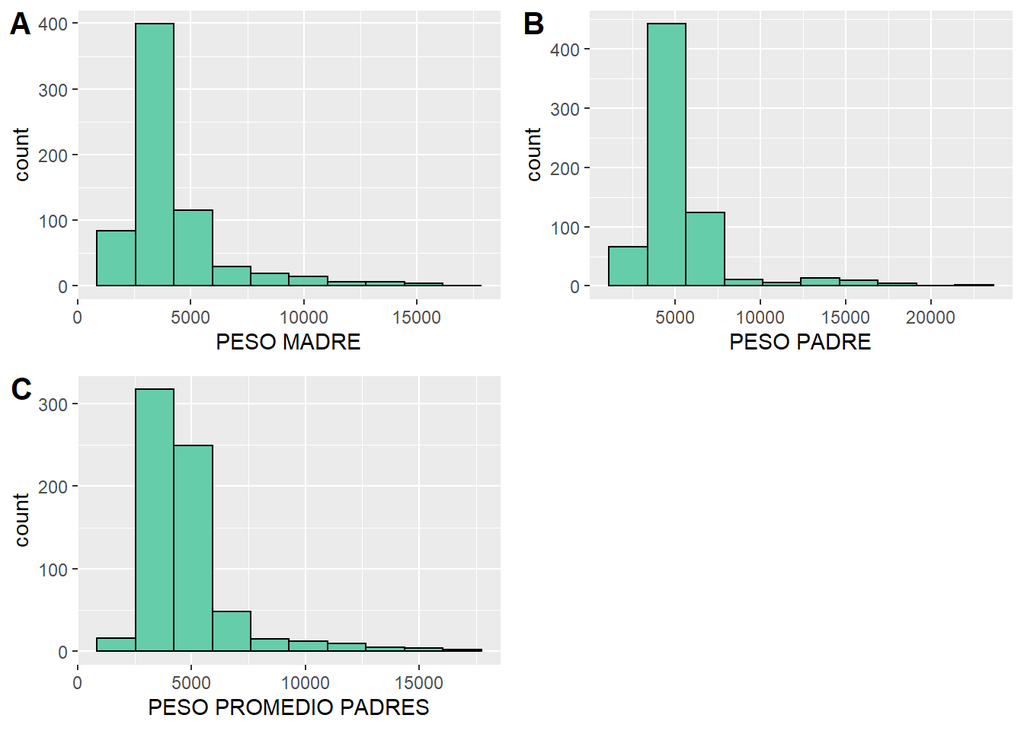

Figura 1. Variables relacionadas con los reproductores.

```r
PlotPM <- ggplot(FDL2E1YC, aes(x=`PESO MADRE`))+
  geom_histogram(color="black", fill="aquamarine3", bins = 10)
PlotPP <- ggplot(FDL2E1YC, aes(`PESO PADRE`))+
  geom_histogram(color="black", fill="aquamarine3", bins = 10)
PlotPMP <- ggplot(FDL2E1YC, aes(`PESO PROMEDIO PADRES`))+
  geom_histogram(color="black", fill="aquamarine3", bins = 10)

ggdraw() +
  draw_plot(PlotPM, x = 0, y = .5, width = .5, height = .5) +
  draw_plot(PlotPP, x = .5, y = .5, width = .5, height = .5) +
  draw_plot(PlotPMP, x = 0, y = 0, width = .5, height = 0.5) +
  draw_plot_label(label = c("A", "B", "C"), size = 15,
                  x = c(0, 0.5, 0), y = c(1, 1, 0.5))
```

### 4.2. Variables relacionadas con la reproducción.

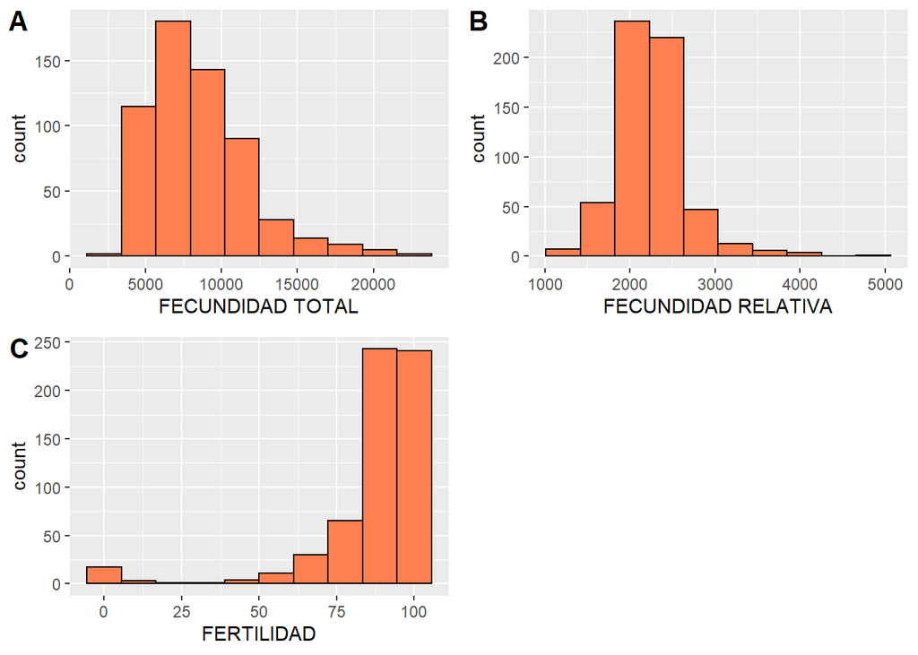

Figura 2. Variables relacionadas con la reproducción.

```r
PlotFC <- ggplot(FDL2E1YC, aes(x=`FECUNDIDAD TOTAL`))+
  geom_histogram(color="black", fill="coral", bins = 10)
PlotFR <- ggplot(FDL2E1YC, aes(`FECUNDIDAD RELATIVA`))+
  geom_histogram(color="black", fill="coral", bins = 10)
PlotFT <- ggplot(FDL2E1YC, aes(`FERTILIDAD`))+
  geom_histogram(color="black", fill="coral", bins = 10)

ggdraw() +
  draw_plot(PlotFC, x = 0, y = .5, width = .5, height = .5) +
  draw_plot(PlotFR, x = .5, y = .5, width = .5, height = .5) +
  draw_plot(PlotFT, x = 0, y = 0, width = .5, height = 0.5) +
  draw_plot_label(label = c("A", "B", "C"), size = 15,
                  x = c(0, 0.5, 0), y = c(1, 1, 0.5))
```

### 4.3. Variables relacionadas con la calidad de las ovas.

Respecto de la calidad de las ovas, podemos observar que el tamaño de estas, medido por el diámetro de la ova, oscila entre 4-6mm. Asimismo, la mayor frecuencia para el volumen de la ova se encuentra entre los 2-3L. El peso de las ovas, por otro lado, presenta en su mayoría valores de entre los 0.5-1.5kg. Por último, el número de ovas que hay en 30cm oscila mayormente entre las 55-65, lo que permite estimar los milímetros que miden en promedio las ovas.

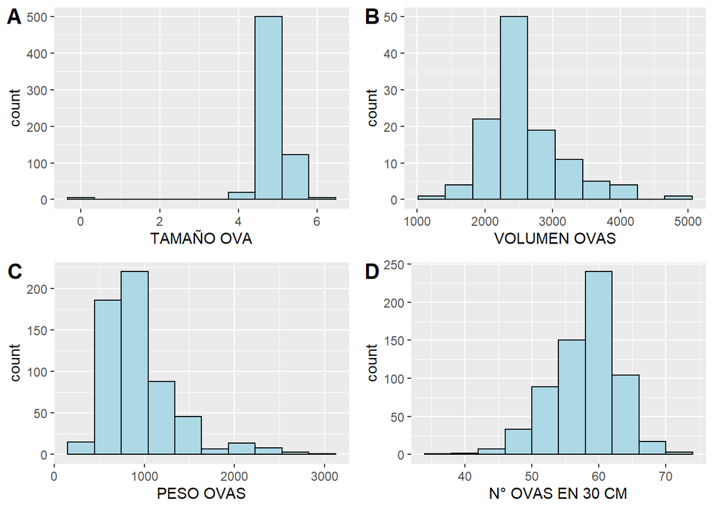

Figura 3. Variables relacionadas con la calidad de las ovas.

```r
PlotTO <- ggplot(FDL2E1YC, aes(x=`TAMAÑO OVA`))+
  geom_histogram(color="black", fill="lightblue", bins = 10)
PlotVO <- ggplot(FDL2E1YC, aes(`VOLUMEN OVAS`))+
  geom_histogram(color="black", fill="lightblue", bins = 10)
PlotPO <- ggplot(FDL2E1YC, aes(`PESO OVAS`))+
  geom_histogram(color="black", fill="lightblue", bins = 10)
PlotNO <- ggplot(FDL2E1YC, aes(`N° OVAS EN 30 CM`))+
  geom_histogram(color="black", fill="lightblue", bins = 10)

ggdraw() +
  draw_plot(PlotTO, x = 0, y = .5, width = .5, height = .5) +
  draw_plot(PlotVO, x = .5, y = .5, width = .5, height = .5) +
  draw_plot(PlotPO, x = 0, y = 0, width = .5, height = 0.5) +
  draw_plot(PlotNO, x = .5, y = 0, width = .5, height = 0.5) +
  draw_plot_label(label = c("A", "B", "C", "D"), size = 15,
                  x = c(0, 0.5, 0, 0.5), y = c(1, 1, 0.5, 0.5))
```

### 4.4. Variables relacionadas con la viabilidad de las ovas.

Respecto de la viabilidad de las ovas, un número mínimo de ovas murieron durante los 4 años evaluados, con valores oscilando mayormente entre las 0-1mil ovas muertas. De las ovas sobrevivientes la mayoría fueron seleccionadas para el Programa de Mejora Genética. En cuanto a la producción de ovas, en su mayoría los padres produjeron entre 5-10mil ovas. Por último, respecto de la supervivencia de las ovas, medida con base en la visualización del ojo del embrión, se observa que en su mayoría sobreviven entre el 60-100% de las ovas.

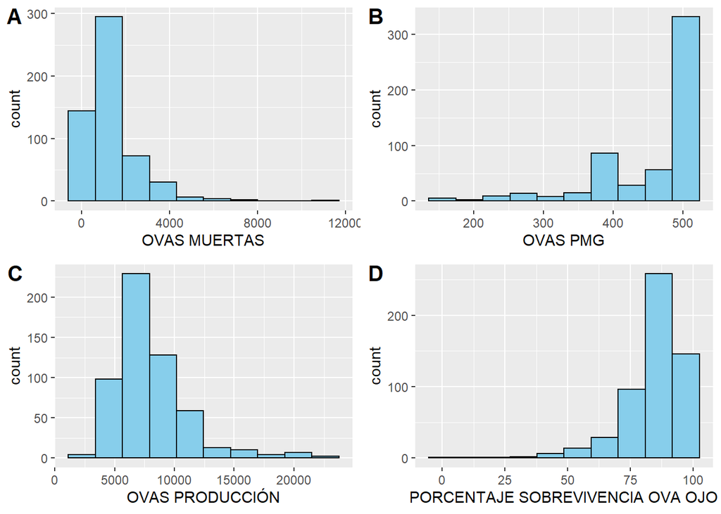

Figura 4. Variables relacionadas con la viabilidad de las ovas.

```r
PlotOM <- ggplot(FDL2E1YC, aes(x=`OVAS MUERTAS`))+
  geom_histogram(color="black", fill="skyblue", bins = 10)
PlotOPM <- ggplot(FDL2E1YC, aes(`OVAS PMG`))+
  geom_histogram(color="black", fill="skyblue", bins = 10)
PlotOPR <- ggplot(FDL2E1YC, aes(`OVAS PRODUCCIÓN`))+
  geom_histogram(color="black", fill="skyblue", bins = 10)
PlotPS <- ggplot(FDL2E1YC, aes(`PORCENTAJE SOBREVIVENCIA OVA OJO`))+
  geom_histogram(color="black", fill="skyblue", bins = 10)

ggdraw() +
  draw_plot(PlotOM, x = 0, y = .5, width = .5, height = .5) +
  draw_plot(PlotOPM, x = .5, y = .5, width = .5, height = .5) +
  draw_plot(PlotOPR, x = 0, y = 0, width = .5, height = 0.5) +
  draw_plot(PlotPS, x = .5, y = 0, width = .5, height = 0.5) +
  draw_plot_label(label = c("A", "B", "C", "D"), size = 15,
                  x = c(0, 0.5, 0, 0.5), y = c(1, 1, 0.5, 0.5))
```

### 4.5. Variables relacionadas con la supervivencia de alevines.

Respecto de la supervivencia de los alevines, se puede observar que la mortalidad, desde la observación de supervivencia de la ova por el ojo del embrión hasta la etapa que este comienza a comer, tiene una baja frecuencia, ya que en los años evaluados solo se observa una mortalidad de entre 0-30 individuos. Por ende, se obtienen, en su mayoría, cada año evaluado, alrededor de 500 individuos sanos y que sobreviven hasta después de la etapa en que comienzan a comer. Por lo que el porcentaje de mortalidad de alevines, es también muy bajo, entre el 0-5%.

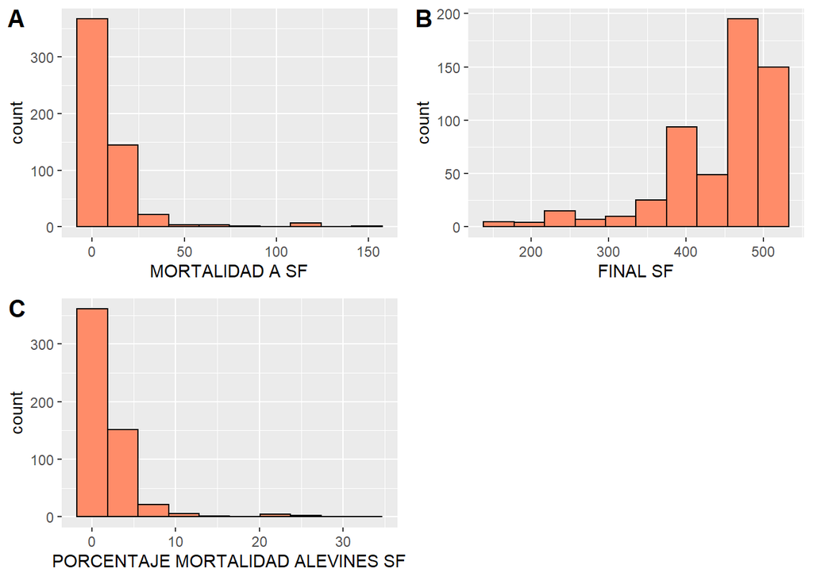

Figura 5. Variables relacionadas con la supervivencia de alevines.

```r
PlotMA <- ggplot(FDL2E1YC, aes(x=`MORTALIDAD A SF`))+
  geom_histogram(color="black", fill="salmon1", bins = 10)
PlotFSF <- ggplot(FDL2E1YC, aes(`FINAL SF`))+
  geom_histogram(color="black", fill="salmon1", bins = 10)
PlotPMA <- ggplot(FDL2E1YC, aes(`PORCENTAJE MORTALIDAD ALEVINES SF`))+
  geom_histogram(color="black", fill="salmon1", bins = 10)

ggdraw() +
  draw_plot(PlotMA, x = 0, y = .5, width = .5, height = .5) +
  draw_plot(PlotFSF, x = .5, y = .5, width = .5, height = .5) +
  draw_plot(PlotPMA, x = 0, y = 0, width = .5, height = 0.5) +
  draw_plot_label(label = c("A", "B", "C"), size = 15,
                  x = c(0, 0.5, 0), y = c(1, 1, 0.5))
```

## 5. Relación entre variables cuantitativas y factores.

En este punto procederemos a realizar evaluaciones visuales entre las variables y factores de nuestra base de datos. Para el caso del los siguientes análisis tomaremos como variables respuesta el peso de los padres.

### 5.1. Evaluación del tamaño de los efectos.

En esta sección se optó por evaluar el efecto del fotoperíodo y de la línea de cultivo, sobre el peso de padres y madres.

### 5.1.1. Tamaño de los efectos sobre el peso de padres.

Se observa que la media se encuentra cerca de los 5.2kg, vemos que el someter a los peces a fotoperíodo tiene un efecto sobre el peso, además el hecho de que los peces pertenezcan a la L3 también tiene mayor efecto sobre la variable peso de los padres, esto respecto del efecto que tiene pertenecer a la L2 y no someter los peces a fotoperíodo.

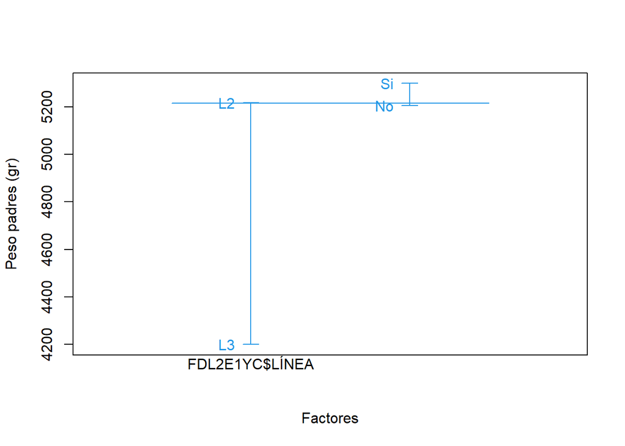

```r
plot.design(FDL2E1YC$`PESO PADRE`~FDL2E1YC$`LÍNEA`*FDL2E1YC$`FOTOPERÍODO`, xlab="Factores", ylab="Peso padres (gr)", col=4:3)
```

### 5.1.2. Tamaño de los efectos sobre el peso de madres.

Se observa que la media se encuentra cerca de los 4.1kg. Al igual que en el caso anterior, vemos que tanto el someter a los peces a fotoperíodo, cómo el hecho de que los peces pertenezcan a la L3, tiene mayor efecto sobre la variable peso de los padres, que la L2 y que no somoter los peces a fotoperíodo.

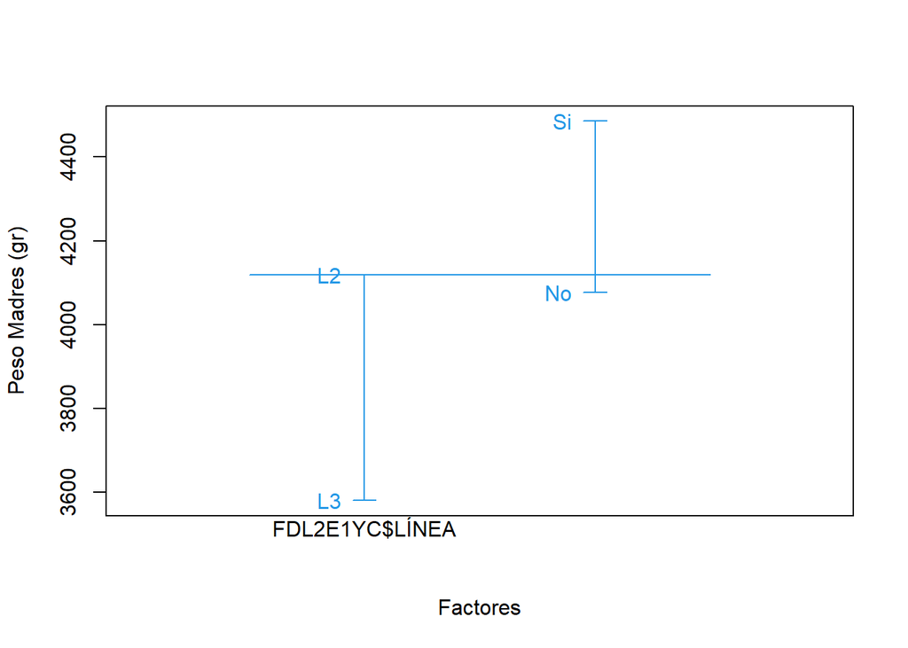

```r
plot.design(FDL2E1YC$`PESO MADRE`~FDL2E1YC$`LÍNEA`*FDL2E1YC$`FOTOPERÍODO`, xlab="Factores", ylab="Peso Madres (gr)", col=4:3)
```

### 5.2. Boxplot.

### 5.2.1. Relación entre Peso de los padres y año de evaluación.

A partir del gráfico y la tabla de resumen presentada a continuación para la variable de peso de los padres, podemos ver que para el **año 2019 no se observan valores o datos atípicos como sucede en los años anteriores**. Siendo que **la mayor variabilidad de los datos, dada por la presencia de valores atípicos, se observa en el año 2010**, año que corresponde al inicio del PMG y por ende a la población inicial, lo que puede ser la causa de esa variabilidad, donde se observan valores atípicos como individuos con peso de hasta más de 20kg. Aquí resalta que **en el año 2016 la media fue 400gr superior a la media observada en 2019**, sin embargo el peso máximo para el año 2016 no supero los 7kg, esto sin considerar los datos atípicos que incluyen una minoría de individuos de hasta 15kg, mientras que **en 2019 se observa un peso máximo de 8.4kg**, sin incluir o considerar datos atípicos o variabilidad. Esto es un indicio de que el Programa de Mejora Genética ha permitido incrementar el peso promedio de los padres.

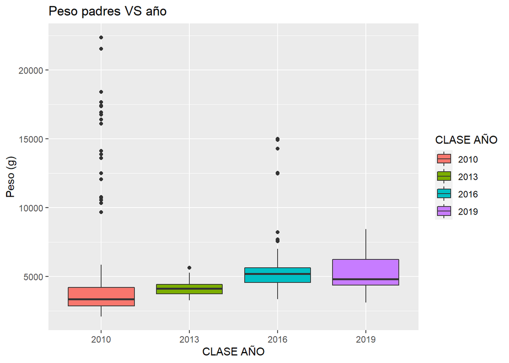

Figura 6. Peso de los padres VS año de evaluación.

```r
ggplot(FDL2E1YC, aes(x = `CLASE AÑO`, y = `PESO PADRE`, fill = `CLASE AÑO`))+
  geom_boxplot()+
  ggtitle("Peso padres VS año")+
  labs(y="Peso (g)")
```

```r
 # geom_jitter(size=0.5)
```

### 5.2.1.1. Resumen estadístico descriptivo.

```r
PePad1 <- FDL2E1YC %>% group_by(`CLASE AÑO`) %>% summarise("N" = n(), "Promedio"= mean(`PESO PADRE`), "Mediana"= median(`PESO MADRE`), "Min." = min(`PESO MADRE`), "Max." = max(`PESO MADRE`), "DS" = sd(`PESO MADRE`))

names(PePad1)[names(PePad1) == 'CLASE AÑO'] <- 'Año'

knitr::kable(PePad1, caption = "Tabla 7. Resumen de peso de los padres por año.")
```

[output not shown]

### 5.2.2. Relación entre peso de las madres y año de evaluación.

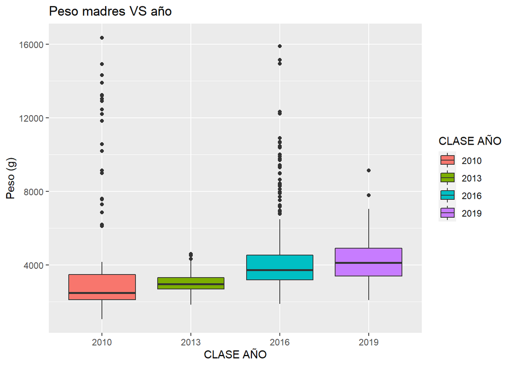

Figura 7. Peso de las madres VS año de evaluación.

```r
ggplot(FDL2E1YC, aes(x = `CLASE AÑO`, y = `PESO MADRE`, fill = `CLASE AÑO`))+
  geom_boxplot()+
  ggtitle("Peso madres VS año")+
  labs(y="Peso (g)")
```

### 5.2.2.1. Resumen estadístico descriptivo.

```r
PeMad1 <- FDL2E1YC %>% group_by(`CLASE AÑO`) %>% summarise("N" = n(), "Promedio"= mean(`PESO MADRE`), "Mediana"= median(`PESO MADRE`), "Min." = min(`PESO MADRE`), "Max." = max(`PESO MADRE`), "DS" = sd(`PESO MADRE`))

names(PeMad1)[names(PeMad1) == 'CLASE AÑO'] <- 'Año'

knitr::kable(PeMad1, caption = "Tabla 8. Resumen de peso de las madres por año.")
```

Tabla 8. Resumen de peso de las madres por año.

| Año | N | Promedio | Mediana | Min. | Max. | DS |
| --- | --- | --- | --- | --- | --- | --- |
| 2010 | 90 | 4380.778 | 2480 | 1060 | 16360 | 3934.6054 |
| 2013 | 117 | 3012.735 | 2960 | 1840 | 4600 | 530.0287 |
| 2016 | 290 | 4489.241 | 3730 | 1880 | 15900 | 2326.0499 |
| 2019 | 181 | 4239.066 | 4120 | 2080 | 9140 | 1101.0071 |

### 5.2.3. Relación entre peso promedio de ambos padres y año de evaluación.

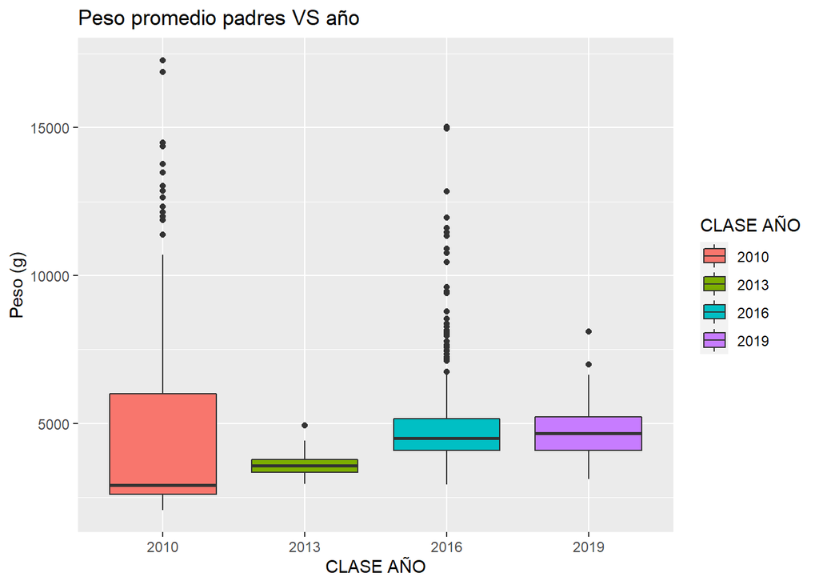

Figura 8. Peso promedio de los padres VS año de evaluación.

```r
ggplot(FDL2E1YC, aes(x = `CLASE AÑO`, y = `PESO PROMEDIO PADRES`, fill = `CLASE AÑO`))+
  geom_boxplot()+
  ggtitle("Peso promedio padres VS año")+
  labs(y="Peso (g)")
```

### 5.2.3.1. Resumen estadístico descriptivo.

```r
PePMad1 <- FDL2E1YC %>% group_by(`CLASE AÑO`) %>% summarise("N" = n(), "Promedio"= mean(`PESO PROMEDIO PADRES`), "Mediana"= median(`PESO PROMEDIO PADRES`), "Min." = min(`PESO PROMEDIO PADRES`), "Max." = max(`PESO PROMEDIO PADRES`), "DS" = sd(`PESO PROMEDIO PADRES`))

names(PePMad1)[names(PePMad1) == 'CLASE AÑO'] <- 'Año'

knitr::kable(PePMad1, caption = "Tabla 8. Resumen de peso de las madres por año.")
```

| Año | N | Promedio | Mediana | Min. | Max. | DS |
| --- | --- | --- | --- | --- | --- | --- |
| 2010 | 90 | 5128.556 | 2925 | 2080 | 17280 | 4180.8976 |
| 2013 | 117 | 3568.932 | 3570 | 2950 | 4930 | 335.1350 |
| 2016 | 290 | 5058.552 | 4505 | 2940 | 15030 | 1823.6991 |
| 2019 | 181 | 4748.787 | 4670 | 3120 | 8100 | 895.2569 |

### 5.3. Correlación.

Aquí se muestran las variables entre las que se encontró una mayor correlación.

### 5.3.1. Correlación entre Peso padres y Peso ovas.

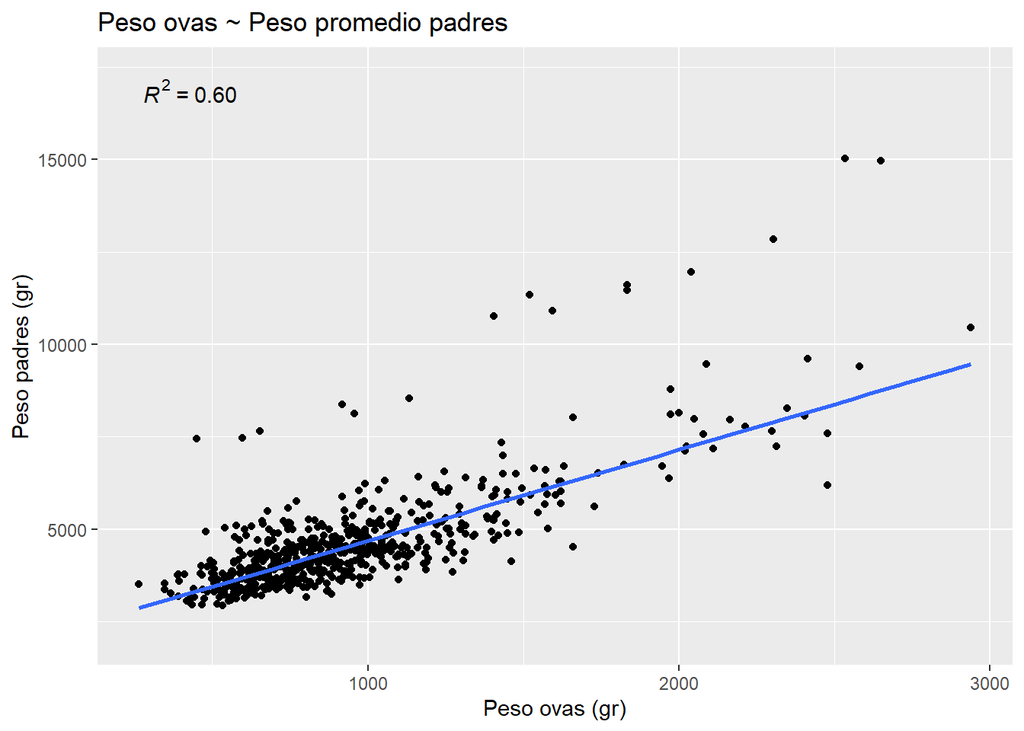

```r
ggplot(FDL2E1YC, aes(x = `PESO OVAS`, y = `PESO PROMEDIO PADRES`)) +
  stat_poly_eq() +
  geom_point() +
  geom_smooth(method=rlm, se=FALSE) +
  labs(title = "Peso ovas ~ Peso promedio padres", x= "Peso ovas (gr)", y= "Peso padres (gr)")
```

### 5.3.2. Correlación entre Peso padres y Ovas producidas.

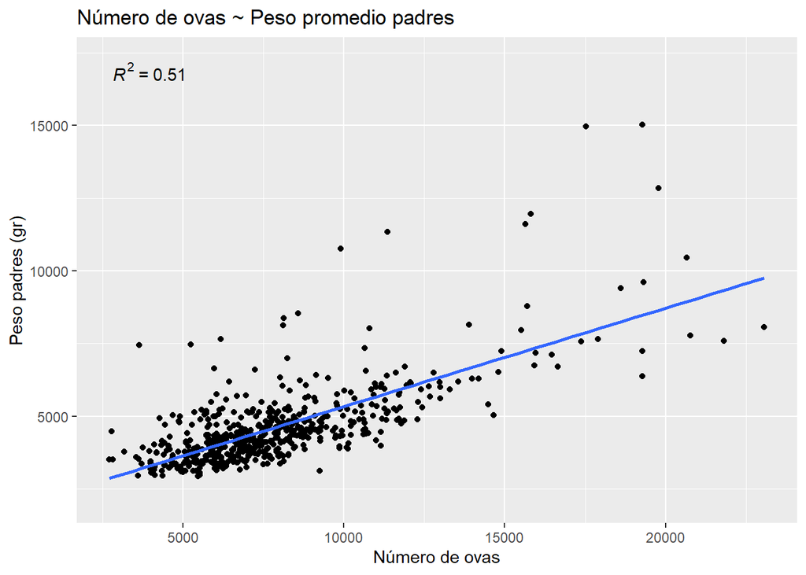

```r
ggplot(FDL2E1YC, aes(x = `OVAS PRODUCCIÓN`, y = `PESO PROMEDIO PADRES`)) +
  geom_point() +
  stat_poly_eq() +
  geom_smooth(method=lm, se=FALSE) +
  labs(title = "Número de ovas ~ Peso promedio padres", x= "Número de ovas", y= "Peso padres (gr)")
```

### 5.3.3. Correlación entre Ovas producidas y Peso ovas.

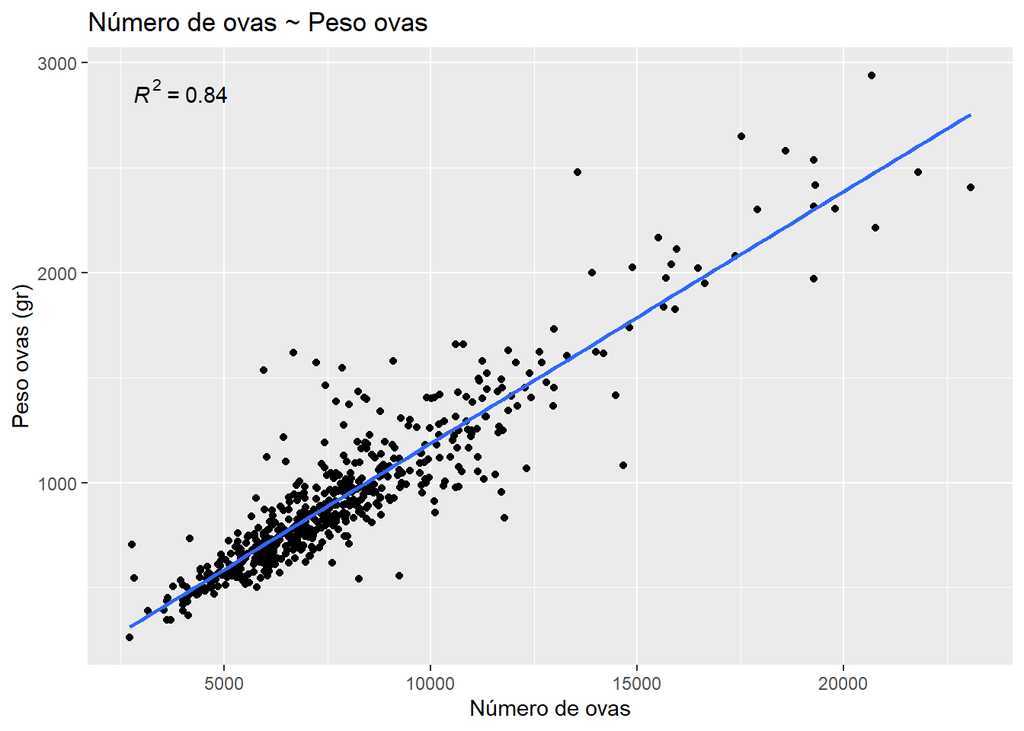

```r
ggplot(FDL2E1YC, aes(x = `OVAS PRODUCCIÓN`, y = `PESO OVAS`)) +
  geom_point() +
  stat_poly_eq() +
  geom_smooth(method=lm, se=FALSE) +
  labs(title = "Número de ovas ~ Peso ovas", x= "Número de ovas", y= "Peso ovas (gr)")
```